# Reaching Future Hospitality Leaders

Collins College Enrollment & Retention · AO4 Proposal Presentation

Jake Evans

IBM 6500, Cal Poly Pomona

2026-10-04

# Introduction

## Background & Business Problem

1,204 → 434

CCHM enrollment, 2015–16 to 2025–26 (-64%)

~28,000

Cal Poly Pomona enrollment overall: relatively steady

The decline is **college-specific**, not campus-wide.

. . .

Strong, under-communicated assets:

- PolyX teaching restaurant built into the curriculum
- Wine, spirits & beer courses; wine auditorium & library
- Off-campus industry visits and a SoCal alumni network
- Dean’s Board of Advisors of industry executives

## Problem Statement

Two connected problems:

- **Attract:** fewer new students, and the college’s channels don’t consistently showcase what makes CCHM unique
- **Retain:** many current students have limited involvement outside class

> Enrollment and retention are one connected problem: the experiences that keep current students engaged are the same ones we promote to prospects.

## Project Objectives

**PO1 · Enrollment**

Grow CCHM toward the Dean’s goal of **~600 students**, about +166 from today.

**PO2 · Retention**

Raise engagement and sense of belonging, especially among first-time freshmen.

**PO3 · Awareness**

Increase prospective-student awareness through content tied to campus and industry events.

## Four AOs Across the Student Journey

| Stage | Framework | Analytics Objective | Owner |
| --- | --- | --- | --- |
| Predisposition & search (pre-application) | Hossler & Gallagher, phases 1–2 | **AO4** · Which digital channels and content themes generate awareness and inquiry | Jake Evans |
| Choice (application → enrollment) | Hossler & Gallagher, phase 3 | **AO3** · Courses most associated with attrition and retention | Aldo Naranjo |
| Persistence (enrolled students) | Tinto’s Student Integration Model | **AO1** · Belonging content and retention | Ruben Garcia |
| Persistence (enrolled students) | Tinto’s Student Integration Model | **AO2** · Transfer vs. first-time freshman retention | Nik Sahami |

## AO4: The Analytics Objective

Which **digital channels** and **content themes**

most effectively generate prospective-student

**awareness and inquiry** for the Collins College?

## Why It Matters

- Inquiry is the **first observable sign of interest**: the top of the enrollment funnel PO1 depends on
- Every later stage (application, admission, enrollment) is drawn from the inquiry pool
- The college has limited marketing resources, so knowing **what to post and where** is worth more than posting more<sup>1</sup>
- The first UTM-tagged campaign post is planned for **October 8, 2026**
[^1]: Lund (2019) found posting volume had a negligible correlation with engagement across 50 universities.

# Literature Review

## Well-Established Models

**Three-phase model of college choice**

Hossler and Gallagher (1987): predisposition → search → choice.

AO4 sits in phases 1–2, before a student applies. The model explains *where* inquiry happens in the decision process.

**Content coding + proportional engagement**

Peruta and Shields (2018): 17 content categories, 7 formats, and engagement ÷ followers.

Fills the gap the college-choice model leaves: *which* messages move a student from awareness to inquiry.

## Evidence Supporting the Approach

- **Content matters.** Content category, format, and timing all predicted engagement across 5,932 posts (Peruta and Shields 2018)
- **The website is the stable core channel.** 90.3% of students used the official .edu site (Shields and Peruta 2019)
- **Authentic beats promotional.** Curriculum and day-in-the-life content rated most impactful (Ozelie and Knuth 2025)
- **Effects show up early.** Social media is most influential at the initial-interest stage (de los Reyes 2023)
- **A comparable design exists.** One department, 58 posts, IRB-exempt public data (Mishnick and Wise 2024)

## Evidence Challenging the Approach

- Posting volume ≈ no effect; prestige and endowment dominate (Lund 2019)
- Social media’s value rose mainly when in-person channels closed (Ng 2023)
- Students and third parties generate most messaging about a school (Bélanger et al. 2014)
- Paid search can’t buy past low brand recognition (Taylor and Bicak 2020)
- Website effects may work only through mediators like usability (Eveleth et al. 2015)

Takeaway: *what* we post matters more than *how much*, and effects will be modest.

## Adequacy of the Gathered Evidence

**Show the chart code**

```r
coverage <- evidence |>
  pivot_longer(starts_with("iv_"), names_to = "iv", values_to = "covered") |>
  filter(covered) |>
  mutate(iv = recode(iv,
                     iv_channel = "Channel & medium",
                     iv_theme   = "Content theme",
                     iv_format  = "Creative format",
                     iv_timing  = "Publication timing")) |>
  count(iv, matrix)

ggplot(coverage, aes(x = n, y = fct_reorder(iv, n, .fun = sum), fill = matrix)) +
  geom_col(width = 0.65) +
  scale_fill_manual(values = c(Supporting = "#1e4d2b", Challenging = "#c99700")) +
  scale_x_continuous(breaks = 0:10, expand = expansion(mult = c(0, 0.05))) +
  labs(x = "Number of sources", y = NULL, fill = NULL,
       title = "Which AO4 independent variables does the evidence base address?") +
  theme_minimal(base_size = 18) +
  theme(legend.position = "top", panel.grid.major.y = element_blank())
```

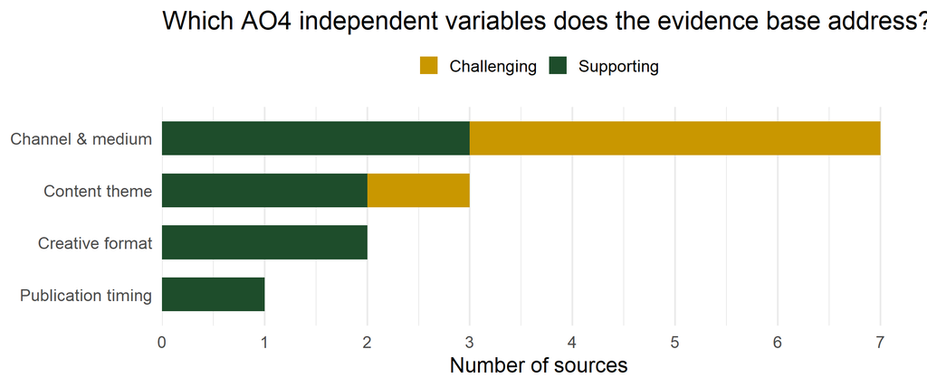

Of 11 sources reviewed (5 supporting, 6 challenging), **0 measure inquiry** as the outcome. Only 6 are U.S.-based, and 6 were published since 2020.

## What the Studies Actually Measured

| Outcome measured | Sources |
| --- | --- |
| Self-report | 4 |
| Platform engagement | 3 |
| Behavioral intention | 1 |
| Literature review | 1 |
| Messaging patterns | 1 |
| Web traffic | 1 |

None of these is **inquiry**. Cingillioglu et al. (2024) found the same across 43 articles: inquiry is a genuine gap in the literature, not a limit of the search.

## Need for Additional Analysis

- **GA4 pre-campaign baseline**: published research can’t tell us the college’s current channel performance
- **Behavioral data first**: GA4 and platform analytics as primary evidence; the IRB survey explains *why*
- **Control for the application cycle**: seasonal demand is the main competing explanation
- **Sharpen the DV**: form submissions and portal referrals weigh above softer signals

# Methods

## Data and Sampling

**Primary data**

- GA4 with consistent UTM tagging (access via Taylor Uster, Collins Marketing Communications)
- Platform analytics: Facebook, Instagram, X/Twitter, YouTube
- Email and paid advertising metrics
- IRB-approved prospective-student survey

**Sampling frame**

- Unit of analysis: each **campaign post** (or campaign day)
- Window: Fall 2026 – Spring 2027 campaign; analysis Summer 2027
- Every post tagged so inquiries link back to the post that produced them
- **Secondary:** aggregate application, admission, and enrollment counts before vs. after the campaign

## Data Wrangling

The evidence base is coded as one row per source. Reshaping it long lets us count coverage by independent variable:

```r
evidence |>
  pivot_longer(starts_with("iv_"), names_to = "iv", values_to = "covered") |>
  filter(covered) |>
  mutate(iv = recode(iv,
                     iv_channel = "Channel & medium",
                     iv_theme   = "Content theme",
                     iv_format  = "Creative format",
                     iv_timing  = "Publication timing")) |>
  count(iv, matrix)
```

```
# A tibble: 6 × 3
  iv                 matrix          n
  <chr>              <chr>       <int>
1 Channel & medium   Challenging     4
2 Channel & medium   Supporting      3
3 Content theme      Challenging     1
4 Content theme      Supporting      2
5 Creative format    Supporting      2
6 Publication timing Supporting      1
```

## Sample Characteristics (Evidence Base)

| Source | Matrix | N | Unit | Setting |
| --- | --- | --- | --- | --- |
| Bélanger et al. (2014) | Challenging | 106 | Universities | Canada (all universities) |
| Eveleth et al. (2015) | Challenging | 199 | Respondents | Job-recruitment context |
| Lund (2019) | Challenging | 50 | Universities | International (QS top 1000) |
| Taylor & Bicak (2020) | Challenging | 100 | Universities | US national (top 100) |
| Ng (2023) | Challenging | 5,494 | Admitted students | Hong Kong single university |
| Cingillioglu et al. (2024) | Challenging | 43 | Articles | Review (mostly international) |
| Peruta & Shields (2018) | Supporting | 5,932 | Facebook posts | US national (66 institutions) |
| Shields & Peruta (2019) | Supporting | 364 | Students surveyed | US (3 institutions + referrals) |
| de los Reyes (2023) | Supporting | n/r | First-year students | US single private university |
| Mishnick & Wise (2024) | Supporting | 58 | Campaign posts | US single department |
| Ozelie & Knuth (2025) | Supporting | 161 | Graduate students | US professional programs |

Campaign data are not yet collected; this table describes the published evidence. n/r = not reported.

## Measures

| Role | Construct | Operationalization |
| --- | --- | --- |
| **DV (primary)** | Inquiry | Intake form submissions, Bronco Applicant Portal referrals |
| **DV (secondary)** | Inquiry | Engaged program-page sessions, event registrations, email sign-ups |
| **IV** | Channel & medium | Platform; organic, paid, email, or referral traffic |
| **IV** | Content theme | Main subject of the post or page |
| **IV** | Creative format | Static image, carousel, short-form video, text |
| **IV** | Publication timing | Day of week and time of day |
| **Offset** | Reach | Impressions per post |

## Analytics Methods

1. **Primary: negative binomial regression** on post-level inquiry counts, with channel and content theme as main predictors, controlling for timing and reach
2. **Fallback:** if posts are too few, nonparametric group comparisons with effect sizes (following Peruta and Shields 2018), plus descriptive GA4 channel contribution
3. **Secondary funnel:** application→admission and admission→enrollment rates compared before vs. after with **χ² tests and φ** (following de los Reyes 2023), periods matched to the same point in the cycle (Ng 2023)

Realistic expectations: a comparable department drew **fewer than five engagements per post** (Mishnick and Wise 2024).

# References

## References

Bélanger, C. H., S. Bali, and B. Longden. 2014. “How Canadian Universities Use Social Media to Brand Themselves.” *Tertiary Education and Management* 20 (1): 14–29. https://doi.org/10.1080/13583883.2013.852237.

Cingillioglu, I., U. Gal, and A. Prokhorov. 2024. “Social Media Marketing for Student Recruitment: An Algorithmically Sequenced Literature Review.” *Journal of Marketing for Higher Education* 34 (2): 1101–23. https://doi.org/10.1080/08841241.2023.2177789.

de los Reyes, J. 2023. “The Influence of Instagram and Social Media Marketing Engagement on Prospective College Students’ University Selection.” *Strategic Enrollment Management Quarterly* 11 (2): 3–17.

Eveleth, D. M., L. J. Baker-Eveleth, and R. W. Stone. 2015. “Potential Applicants’ Expectation-Confirmation and Intentions.” *Computers in Human Behavior* 44: 183–90. https://doi.org/10.1016/j.chb.2014.11.025.

Hossler, D., and K. S. Gallagher. 1987. “Studying Student College Choice: A Three-Phase Model and the Implications for Policymakers.” *College and University* 62 (3): 207–21.

Lund, B. 2019. “Universities Engaging Social Media Users: An Investigation of Quantitative Relationships Between Universities’ Facebook Followers/Interactions and University Attributes.” *Journal of Marketing for Higher Education* 29 (2): 251–67. https://doi.org/10.1080/08841241.2019.1641875.

Mishnick, N., and D. Wise. 2024. “Social Media Engagement: An Analysis of the Impact of Social Media Campaigns on Facebook, Instagram, and LinkedIn.” *International Journal of Technology in Education* 7 (3): 535–49.

Ng, A. W. Y. 2023. “Changes in the Usefulness of Communication Channels for Prospective Undergraduates about University Studying: Afore and During the Pandemic.” *International Journal of Educational Management* 37 (2): 361–72. https://doi.org/10.1108/IJEM-04-2022-0154.

Ozelie, R., and A. Knuth. 2025. “Harnessing Social Media for Occupational Therapy Graduate Program Recruitment.” *Journal of Occupational Therapy Education* 9 (4).

Peruta, A., and A. B. Shields. 2018. “Marketing Your University on Social Media: A Content Analysis of Facebook Post Types and Formats.” *Journal of Marketing for Higher Education* 28 (2): 175–91. https://doi.org/10.1080/08841241.2018.1442896.

Shields, A. B., and A. Peruta. 2019. “Social Media and the University Decision. Do Prospective Students Really Care?” *Journal of Marketing for Higher Education* 29 (1): 67–83. https://doi.org/10.1080/08841241.2018.1557778.

Taylor, Z. W., and I. Bicak. 2020. “Buying Search, Buying Students: How Elite U.S. Institutions Employ Paid Search to Practice Academic Capitalism Online.” *Journal of Marketing for Higher Education* 30 (2): 271–96. https://doi.org/10.1080/08841241.2020.1731910.

# Appendix

## Links

- [CEP Group 3 project site](https://jakevns.github.io/cep-group3-collins-enrollment-retention/)
- [AO4 Progress Report 1 (PDF)](https://jakevns.github.io/cep-group3-collins-enrollment-retention/assignments/progress-reports/AO4-progress-report-1.pdf)
- [Chapter 1 + Section 2.7 group presentation](https://jakevns.github.io/cep-group3-collins-enrollment-retention/assignments/progress-reports/ch1-sec27-presentation.html)
- [Quarto Reveal.js documentation](https://quarto.org/docs/presentations/revealjs/)
- [CCIDM effective-quarto-slides repo](https://github.com/CCIDM/effective-quarto-slides)
- [Case 31 sample presentation](https://jmjung.quarto.pub/case31-presentatoin/)

Press **S** for speaker notes, **F** for full screen, **Esc** for overview, **Alt/Option + click** to zoom.